# Project Title: Predicting Bike-Sharing Demand: A Weather-Driven Analysis for Capital Bikeshare

Fall24 SI618 Group 17

School of Information, University of Michigan

## Team Members

- Yidan Chang (yidanydc)
- Zhuxin Wu (zhuxinwu)
- Shangqing Wei (weishq)

## Overview

Our project aims to explore and predict the impact of weather conditions on bike-sharing demand using data from the Capital Bikeshare program in Washington, D.C. By combining bike usage data with historical weather data, we seek to understand how factors such as temperature, precipitation, and wind affect the number of daily and hourly bike rentals.

The project involves cleaning and merging the datasets, conducting exploratory data analysis, and applying machine learning models to forecast demand based on weather conditions. Additionally, we will investigate differences in user behavior between casual riders and registered members, and optimize bike allocation across stations based on predicted demand fluctuations. Ultimately, our goal is to provide insights that can help bike-sharing operators better manage resources, improve user experience, and enhance service efficiency.

## Motivation

We selected the Capital Bikeshare dataset combined with weather data because bike-sharing services are an increasingly vital component of urban transportation systems, providing a flexible and eco-friendly option for city dwellers and visitors alike. However, the effectiveness and user satisfaction of these services are highly dependent on various factors, particularly weather conditions. By analyzing how external variables like temperature, precipitation, and wind impact bike-sharing demand, we can develop predictive models to optimize resource management and enhance operational efficiency. Understanding the influence of weather on user behavior could help operators make data-driven decisions to improve service delivery, ultimately benefiting both users and the business.

Through this project, we aim to explore how weather conditions drive bike-sharing demand and how user segments (e.g., casual vs. registered users) react differently to environmental changes. By answering the following key real-world questions, we hope to offer valuable insights into optimizing bike-sharing services in urban areas.

### Three Real-World Questions:

1. **How can we accurately predict daily or hourly bike-sharing demand based on weather conditions?**  
   *By answering this question, we aim to develop a machine learning model that forecasts bike-sharing demand in varying weather conditions. The outcome could help operators prepare for high or low-demand days by adjusting fleet availability, ultimately improving user satisfaction and reducing operational inefficiencies.*
2. **What are the key behavioral differences between casual and registered users in response to different weather conditions?**  
   *This question explores how different types of users—casual riders versus registered members—respond to weather variations. The findings will help operators tailor marketing strategies, promotions, or service adjustments to each group, improving overall ridership and engagement.*
3. **How can we optimize bike distribution across stations by predicting station-level demand fluctuations throughout the day?**  
   *By predicting station-level demand changes based on time of day and weather, we hope to recommend strategies for optimizing bike allocation across different stations, ensuring that bikes are available where and when they are needed most.*

## Data Sources

For this project, we are using four datasets that provide complementary information about bike-sharing usage, station locations, and weather conditions:

1. **Capital Bikeshare Ride Data (May 2020 - August 2024)**  
   This dataset contains detailed records of individual bike rides, including information on ride start and end times, bike types, station information, and user type (casual or registered).
   - **Source**: [Capital Bikeshare System Data](https://capitalbikeshare.com/system-data)
2. **Capital Bikeshare Station List**  
   This dataset includes the list of all stations in the Capital Bikeshare system, including station IDs and names. It is organized from the ride data and provides contextual information for ride start and end locations.
   - **Source**: [Organized from the daily rent data](https://www.kaggle.com/datasets/taweilo/capital-bikeshare-dataset-202005202408/data?select=station_list.csv)
3. **Station Usage Frequency Data**  
   This dataset provides daily counts of bike pickups and drop-offs at each station, offering insights into the usage patterns at specific stations over time.
   - **Source**: [Organized from the ride data](https://www.kaggle.com/datasets/taweilo/capital-bikeshare-dataset-202005202408/data?select=usage_frequency.csv)
4. **Weather Data (May 2020 - August 2024)**  
   This dataset includes weather-related variables for Washington, D.C., such as temperature, precipitation, wind speed, and other conditions that could influence bike usage on a daily basis.
   - **Source**: [Visual Crossing Weather Data](https://www.visualcrossing.com/)

### How the Datasets Complement Each Other

The four datasets complement each other by combining information on bike-sharing behavior, station-level activity, and external factors like weather. The **ride data** provides granular details about individual trips, while the **station list** and **usage frequency data** give station-level context, helping to analyze patterns of bike usage at different locations. The **weather data** adds another layer of information, enabling us to investigate how environmental conditions affect overall demand and station-level activity.

By merging these datasets, we can perform detailed analyses to predict bike-sharing demand, identify trends across different stations, and optimize resource allocation based on weather conditions and usage patterns.

## Data Description

### `daily_rent_detail.csv` dataset

It contains information on individual bike rides from the Capital Bikeshare program from **April 30, 2020** to **August 31, 2024**. The dataset includes **16.1 million records** with detailed information about each ride, including start and end times, bike types, and station data. Below are the key variables of interest:

- **ride_id**: Unique identifier for each ride.  
  *(16.1 million unique values)*
- **rideable_type**: Type of bike used for the ride (e.g., classic bike, electric bike).
  - *60% classic_bike*
  - *29% electric_bike*
  - *12% other*
- **started_at**: Start date and time of the ride.  
  *(Range: April 30, 2020, to August 31, 2024, Mean: November 22, 2022)*
- **ended_at**: End date and time of the ride.  
  *(Range: January 1, 2000, to August 31, 2024, Mean: November 22, 2022)*
- **start_station_name**: Name of the station where the ride started.  
  *(91% valid, 9% missing values)*
- **start_station_id**: Unique identifier for the starting station.  
  *(91% valid, 9% missing values)*
- **end_station_name**: Name of the station where the ride ended.  
  *(90% valid, 10% missing values)*
- **end_station_id**: Unique identifier for the ending station.  
  *(90% valid, 10% missing values)*
- **start_lat**: Latitude of the starting station.  
  *(Valid, no missing values)*
- **start_lng**: Longitude of the starting station.  
  *(Valid, no missing values)*

This dataset provides a wealth of information about bike-sharing behavior, and some variables (like station names and IDs) include missing values that should be addressed during data cleaning. The ride details such as timestamps and geospatial data are crucial for analyzing trip durations, distances, and the impact of various factors (like weather) on bike-sharing demand.

### `station_list.csv` dataset

The `station_list.csv` dataset contains information about the stations in the Capital Bikeshare program. The dataset includes **916 records** with details about the station IDs and names. Below are the key variables of interest:

- **station_id**: Unique identifier for each station.
  - *(Range: 30.2k to 33.2k, Mean: 31.6k)*
- **station_name**: Name of each station.
  - *(912 unique values)*

This dataset provides information necessary to map ride data to specific stations and locations. All records are valid, with no missing values.

### `usage_frequency.csv` dataset

It provides daily pickup and dropoff counts at each station in the Capital Bikeshare system from **April 30, 2020** to **August 30, 2024**. The dataset includes **873,000 records** with information about station names, pickup, and dropoff counts. Below are the key variables of interest:

- **date**: The date for which the data is recorded.  
  *(Range: April 30, 2020, to August 30, 2024)*
- **station_name**: The name of the station where the pickups and dropoffs occurred.  
  *(908 unique station names)*
- **pickup_counts**: The daily count of pickups at the station.  
  *(Range: 1 to 444, Mean: 16.8)*
- **dropoff_counts**: The daily count of dropoffs at the station.  
  *(Range: 0 to 460, Mean: 16.6)*

This dataset helps analyze the usage patterns at specific stations over time. All records are valid with no missing or mismatched values.

### `Weather` Data

The weather dataset used in this project contains historical weather data for Washington, D.C., from **April 30, 2020** to **August 30, 2024**. The dataset includes **1,584 records** and contains no missing or mismatched values. Below are the key variables of interest:

- **datetime**: Date corresponding to the weather data.
- **tempmax**: Maximum temperature recorded at the location (°C). *(Range: -6.2°C to 39.3°C, Mean: 20.9°C)*
- **tempmin**: Minimum temperature recorded at the location (°C).  
  *(Range: -12.9°C to 27.5°C, Mean: 12°C)*
- **temp**: Average daily temperature (°C).  
  *(Range: -9.7°C to 32.7°C, Mean: 16.2°C)*
- **feelslikemax**: Maximum "feels like" temperature accounting for heat index or wind chill (°C).  
  *(Range: -11.1°C to 43.4°C, Mean: 21.1°C)*
- **feelslikemin**: Minimum "feels like" temperature (°C).  
  *(Range: -20.2°C to 31°C, Mean: 10.7°C)*
- **feelslike**: Average "feels like" temperature for the day (°C).  
  *(Range: -16.4°C to 36.3°C, Mean: 15.7°C)*
- **dew**: Dew point temperature (°C).  
  *(Range: -19.2°C to 24.2°C, Mean: 9.73°C)*
- **humidity**: Relative humidity as a percentage.  
  *(Range: 24.3% to 96.9%, Mean: 63.8%)*

## Data Manipulation

In this step, the main things we want to do are:

1. data filtering: The data we need is
   - weather data from 2023-05-01 to 2024-05-01
   - usage_frequency data from 2023-05-01 to 2024-05-31
   - daily rent data from 2024-05-01 to 2024-05-31
   - station_list data
2. data format conversion
3. data merging
4. basic data cleaning

### Loading Packages and Dataset

```python
import pandas as pd
import numpy as np
import matplotlib.pyplot as plt
import seaborn as sns
```

```python
datetag1 = '2023-05-01 00:00:00'
datetag2 = '2024-05-01 00:00:00'
datetag3= '2024-05-31 23:59:59'
```

```python
usage_frequency=pd.read_csv('bikeshare/usage_frequency.csv')
station_list=pd.read_csv('bikeshare/station_list.csv')
weather=pd.read_csv('bikeshare/weather.csv')
```

Our original dataset contains a table showing the rental records for each stations. This table has too much data, so we perform an initial data filter at the data import stage.

We chose data from 2024-05-01 to 2024-05-31 to ensure that our dataset would be current while still covering the fluctuating changes in rentals over a full week (we initially assume that there might be some differences in the bikeshare data during the week and on weekends).

```python
# this step will output a filtered csv file
# we will use the output file in the following steps

# date_cols = ['started_at']
# data = pd.read_csv('bikeshare/daily_rent_detail.csv', parse_dates=['started_at'])

# filtered_data = data[(data['started_at'] >= datetag2) & (data['started_at'] <= datetag3)]
# filtered_data.to_csv('bikeshare/daily_rent_detail_240531.csv', index=False)
```

```python
rent_data = pd.read_csv('bikeshare/daily_rent_detail_240531.csv')
```

### Data Display

```python
usage_frequency.head()
```

|  | date | station_name | pickup_counts | dropoff_counts |
| --- | --- | --- | --- | --- |
| 0 | 2020-05-01 | 10th & E St NW | 11 | 7.0 |
| 1 | 2020-05-01 | 10th & Florida Ave NW | 8 | 8.0 |
| 2 | 2020-05-01 | 10th & G St NW | 3 | 2.0 |
| 3 | 2020-05-01 | 10th & K St NW | 12 | 15.0 |
| 4 | 2020-05-01 | 10th & Monroe St NE | 5 | 6.0 |

```python
usage_frequency.info()
```

```
<class 'pandas.core.frame.DataFrame'>
RangeIndex: 873318 entries, 0 to 873317
Data columns (total 4 columns):
 #   Column          Non-Null Count   Dtype
---  ------          --------------   -----
 0   date            873318 non-null  object
 1   station_name    873318 non-null  object
 2   pickup_counts   873318 non-null  int64
 3   dropoff_counts  873318 non-null  float64
dtypes: float64(1), int64(1), object(2)
memory usage: 26.7+ MB
```

```python
rent_data.head()
```

|  | ride_id | rideable_type | started_at | ended_at | start_station_name | start_station_id | end_station_name | end_station_id | start_lat | start_lng | end_lat | end_lng | member_casual |
| --- | --- | --- | --- | --- | --- | --- | --- | --- | --- | --- | --- | --- | --- |
| 0 | 028CB30D63626320 | classic_bike | 2024-05-23 16:07:47 | 2024-05-23 16:20:22 | Grant Circle | 31421.0 | 10th & Quincy St NE / Turkey Thicket Rec | 31541.0 | 38.942025 | -77.018221 | 38.937849 | -76.993509 | casual |
| 1 | 33D6F7F8951D5D67 | electric_bike | 2024-05-24 09:19:05 | 2024-05-24 10:02:29 | W Columbia St & N Washington St | 32609.0 | S Glebe Rd & Potomac Ave | 31010.0 | 38.885602 | -77.166884 | 38.842600 | -77.050200 | casual |
| 2 | BDDEFEBB8770EFF2 | classic_bike | 2024-05-09 08:54:14 | 2024-05-09 08:59:16 | 1st & L St NW | 31677.0 | New Jersey Ave & F St NW | 31655.0 | 38.903819 | -77.011987 | 38.897108 | -77.011616 | member |
| 3 | 31C46CFE02542EF5 | classic_bike | 2024-05-16 13:48:38 | 2024-05-16 14:04:43 | North Capitol & R St NE | 31527.0 | 10th & Quincy St NE / Turkey Thicket Rec | 31541.0 | 38.912560 | -77.008775 | 38.937849 | -76.993509 | member |
| 4 | 3DB767AB9DF69BD7 | electric_bike | 2024-05-22 08:27:00 | 2024-05-22 08:38:24 | Eastern Market / 7th & North Carolina Ave SE | 31610.0 | New Jersey Ave & F St NW | 31655.0 | 38.887016 | -76.996802 | 38.897108 | -77.011616 | member |

```python
rent_data.info()
```

```
<class 'pandas.core.frame.DataFrame'>
RangeIndex: 515535 entries, 0 to 515534
Data columns (total 13 columns):
 #   Column              Non-Null Count   Dtype
---  ------              --------------   -----
 0   ride_id             515535 non-null  object
 1   rideable_type       515535 non-null  object
 2   started_at          515535 non-null  object
 3   ended_at            515535 non-null  object
 4   start_station_name  436789 non-null  object
 5   start_station_id    436789 non-null  float64
 6   end_station_name    433527 non-null  object
 7   end_station_id      433407 non-null  float64
 8   start_lat           515535 non-null  float64
 9   start_lng           515535 non-null  float64
 10  end_lat             515113 non-null  float64
 11  end_lng             515113 non-null  float64
 12  member_casual       515535 non-null  object
dtypes: float64(6), object(7)
memory usage: 51.1+ MB
```

```python
weather.head()
```

|  | name | datetime | tempmax | tempmin | temp | feelslikemax | feelslikemin | feelslike | dew | humidity | ... | solarenergy | uvindex | severerisk | sunrise | sunset | moonphase | conditions | description | icon | stations |
| --- | --- | --- | --- | --- | --- | --- | --- | --- | --- | --- | --- | --- | --- | --- | --- | --- | --- | --- | --- | --- | --- |
| 0 | Washington,DC,USA | 2020-05-01 | 18.8 | 11.6 | 14.9 | 18.8 | 11.6 | 14.9 | 8.9 | 69.6 | ... | 9.5 | 6 | NaN | 2020-05-01T06:09:41 | 2020-05-01T20:01:16 | 0.30 | Rain, Partially cloudy | Partly cloudy throughout the day with rain cle... | rain | KDCA,72405013743,72403793728,F0198,KADW,KDAA,7... |
| 1 | Washington,DC,USA | 2020-05-02 | 22.1 | 11.1 | 16.3 | 22.1 | 11.1 | 16.3 | 6.4 | 54.0 | ... | 14.0 | 9 | NaN | 2020-05-02T06:08:30 | 2020-05-02T20:02:13 | 0.33 | Partially cloudy | Partly cloudy throughout the day. | partly-cloudy-day | KDCA,72405013743,72403793728,F0198,KGAI,KADW,K... |
| 2 | Washington,DC,USA | 2020-05-03 | 24.9 | 15.6 | 18.6 | 24.9 | 15.6 | 18.6 | 13.4 | 72.5 | ... | 5.7 | 4 | NaN | 2020-05-03T06:07:21 | 2020-05-03T20:03:11 | 0.37 | Rain, Partially cloudy | Partly cloudy throughout the day with rain. | rain | KDCA,72405013743,72403793728,F0198,KADW,KDAA,7... |
| 3 | Washington,DC,USA | 2020-05-04 | 23.8 | 14.3 | 19.2 | 23.8 | 14.3 | 19.2 | 7.8 | 53.8 | ... | 13.3 | 8 | NaN | 2020-05-04T06:06:12 | 2020-05-04T20:04:08 | 0.40 | Rain, Partially cloudy | Clearing in the afternoon with early morning r... | rain | KDCA,72405013743,72403793728,F0198,KADW,KDAA,7... |
| 4 | Washington,DC,USA | 2020-05-05 | 14.3 | 9.3 | 12.3 | 14.3 | 8.0 | 12.1 | 3.3 | 55.6 | ... | 5.0 | 2 | NaN | 2020-05-05T06:05:06 | 2020-05-05T20:05:05 | 0.44 | Rain, Partially cloudy | Partly cloudy throughout the day with late aft... | rain | KIAD,KDCA,72405013743,72403793728,72403093738,... |

5 rows × 33 columns

```python
weather.info()
```

```
<class 'pandas.core.frame.DataFrame'>
RangeIndex: 1584 entries, 0 to 1583
Data columns (total 33 columns):
 #   Column            Non-Null Count  Dtype
---  ------            --------------  -----
 0   name              1584 non-null   object
 1   datetime          1584 non-null   object
 2   tempmax           1584 non-null   float64
 3   tempmin           1584 non-null   float64
 4   temp              1584 non-null   float64
 5   feelslikemax      1584 non-null   float64
 6   feelslikemin      1584 non-null   float64
 7   feelslike         1584 non-null   float64
 8   dew               1584 non-null   float64
 9   humidity          1584 non-null   float64
```

[output cut: 25 more lines]

```python
station_list.head()
```

|  | station_id | station_name |
| --- | --- | --- |
| 0 | 30200 | 9th St & Pennsylvania Ave NW |
| 1 | 30201 | 9th & G St NW |
| 2 | 31000 | Eads St & 15th St S |
| 3 | 31001 | 18th St & S Eads St |
| 4 | 31002 | Crystal Dr & 20th St S |

```python
station_list.info()
```

```
<class 'pandas.core.frame.DataFrame'>
RangeIndex: 916 entries, 0 to 915
Data columns (total 2 columns):
 #   Column        Non-Null Count  Dtype
---  ------        --------------  -----
 0   station_id    916 non-null    int64
 1   station_name  916 non-null    object
dtypes: int64(1), object(1)
memory usage: 14.4+ KB
```

### Preliminary data-processing

In this step, we did some basic data processing on all tables. This includes removing data from other times according to the study period, modifying the data types of some columns, etc. We hope that after this step, the tables will be able to be merged.

- **For usage_frequency df**：We primarily intercepted data from the study time period. Since we may need to time period, we output data for a month (from 2024-05-01 to 2024-05-31) and a year (from 2023-05-01 to 2024-05-01).
- **For weather df**：We primarily intercepted data from the study time period (from 2023-05-01 to 2024-05-01). And we also remove some columns that we may not need. We have also changed the names of some of the columns for better merge.
- **For rent_data df**：We transfer the station code from float data to int data. During the checking process, we found that some pickup times contain milliseconds information, we would like to remove this useless information. We also extracted the day information from this time column and stored it in a new ‘started_day’ column for subsequent data merging.

```python
usage_frequency['date'] = pd.to_datetime(usage_frequency['date'])

usage_frequency_m = usage_frequency.loc[(usage_frequency['date'] >= datetag2) & (usage_frequency['date'] <= datetag3)]
usage_frequency_m = usage_frequency_m.rename(columns={'station_name': 'start_station_name', 'date': 'started_day'})

usage_frequency_y = usage_frequency.loc[(usage_frequency['date'] >= datetag1) & (usage_frequency['date'] <= datetag2)].copy()
usage_frequency_y.loc[:, 'city_name'] = 'Washington,DC,USA'
```

```python
weather['datetime'] = pd.to_datetime(weather['datetime'])

weather=weather.loc[(weather['datetime']>=datetag1) & (weather['datetime']<=datetag2)]
weather=weather.iloc[:,:-1]
weather.rename(columns={'name':'city_name','datetime':'date'},inplace=True)
```

```python
rent_data['started_at'] = rent_data['started_at'].str.split('.').str[0]
rent_data['ended_at'] = rent_data['ended_at'].str.split('.').str[0]

rent_data['started_at'] = pd.to_datetime(rent_data['started_at'], format="%Y-%m-%d %H:%M:%S", errors='coerce')
rent_data['ended_at'] = pd.to_datetime(rent_data['ended_at'], format="%Y-%m-%d %H:%M:%S", errors='coerce')
rent_data['started_day'] = rent_data['started_at'].dt.floor('D')


rent_data['start_station_id'] = rent_data['start_station_id'].where(rent_data['start_station_id'].notnull(), None).astype('Int64')
rent_data['end_station_id'] = rent_data['end_station_id'].where(rent_data['end_station_id'].notnull(), None).astype('Int64')
```

### Merging Data

In our analysis, we roughly merge the table into two dataframes based on the correlation between the data.

- (1) We selected one year of weather and merged the pickup & dropoff records of each site for each day of the year period with the site's current weather data.
- (2) We selected a detailed record of rentals for all sites over a month period and combined it with the total rentals for each site for each day. We mainly observed where they pick up the bikes, so we merged the station data with the starting station of the detail records.

```python
weather_frequency=pd.merge(usage_frequency_y,weather,on=['city_name','date'],how='left')
```

```python
weather_frequency.info()
```

```
<class 'pandas.core.frame.DataFrame'>
RangeIndex: 225801 entries, 0 to 225800
Data columns (total 35 columns):
 #   Column            Non-Null Count   Dtype
---  ------            --------------   -----
 0   date              225801 non-null  datetime64[ns]
 1   station_name      225801 non-null  object
 2   pickup_counts     225801 non-null  int64
 3   dropoff_counts    225801 non-null  float64
 4   city_name         225801 non-null  object
 5   tempmax           225801 non-null  float64
 6   tempmin           225801 non-null  float64
 7   temp              225801 non-null  float64
 8   feelslikemax      225801 non-null  float64
 9   feelslikemin      225801 non-null  float64
```

[output cut: 27 more lines]

```python
detail_frequency=rent_data.merge(usage_frequency_m,on=['start_station_name','started_day'],how='left')
```

```python
detail_frequency.info()
```

```
<class 'pandas.core.frame.DataFrame'>
RangeIndex: 515535 entries, 0 to 515534
Data columns (total 16 columns):
 #   Column              Non-Null Count   Dtype
---  ------              --------------   -----
 0   ride_id             515535 non-null  object
 1   rideable_type       515535 non-null  object
 2   started_at          515535 non-null  datetime64[ns]
 3   ended_at            515535 non-null  datetime64[ns]
 4   start_station_name  436789 non-null  object
 5   start_station_id    436789 non-null  Int64
 6   end_station_name    433527 non-null  object
 7   end_station_id      433407 non-null  Int64
 8   start_lat           515535 non-null  float64
 9   start_lng           515535 non-null  float64
 10  end_lat             515113 non-null  float64
 11  end_lng             515113 non-null  float64
 12  member_casual       515535 non-null  object
 13  started_day         515535 non-null  datetime64[ns]
 14  pickup_counts       436789 non-null  float64
 15  dropoff_counts      436789 non-null  float64
dtypes: Int64(2), datetime64[ns](3), float64(6), object(5)
memory usage: 63.9+ MB
```

After merging operation, we get two main tables:

- **weather_frequency** table: this table contains the daily pickup & dropoff of all the rental stations in one year, as well as the weather condition of the day.
- **detail_frequency** table: this table contains the details of rental records (including rental time, start location, end location, end time, bike type, etc.) of all rental stations for each day in one month, and the overall rental situation of each day of every stations.

### Secondary data processing and data cleansing

After merging the data upfront, we get a lot of null values in our data. In this step we will perform a simple data cleanup on the two tables we merged.

The main part of our work is to work with the null values in the merged table.

- For the **weather_frequency** table, we found that the null values were mainly about the precipitation type. Since it's not the main data we want and the nulls make up a large percentage, we can't just remove them. Therefore, when doing the processing, we chose to fill them with 0.
- For the **detail_frequency** table, the null values are mainly about the start and end locations The records that lack these data cannot be analyzed as we want, so we directly delete this part of the record.

```python
weather_frequency.isnull().sum()[weather_frequency.isnull().any()]
```

```
preciptype    114768
dtype: int64
```

```python
weather_frequency.fillna(0,inplace=True)
```

```python
weather_frequency.info()
```

```
<class 'pandas.core.frame.DataFrame'>
RangeIndex: 225801 entries, 0 to 225800
Data columns (total 35 columns):
 #   Column            Non-Null Count   Dtype
---  ------            --------------   -----
 0   date              225801 non-null  datetime64[ns]
 1   station_name      225801 non-null  object
 2   pickup_counts     225801 non-null  int64
 3   dropoff_counts    225801 non-null  float64
 4   city_name         225801 non-null  object
 5   tempmax           225801 non-null  float64
 6   tempmin           225801 non-null  float64
 7   temp              225801 non-null  float64
 8   feelslikemax      225801 non-null  float64
 9   feelslikemin      225801 non-null  float64
```

[output cut: 27 more lines]

```python
detail_frequency.isnull().sum()[detail_frequency.isnull().any()]
```

```
start_station_name    78746
start_station_id      78746
end_station_name      82008
end_station_id        82128
end_lat                 422
end_lng                 422
pickup_counts         78746
dropoff_counts        78746
dtype: int64
```

```python
detail_frequency.dropna(inplace=True)
```

```python
detail_frequency.info()
```

```
<class 'pandas.core.frame.DataFrame'>
Index: 400814 entries, 0 to 515526
Data columns (total 16 columns):
 #   Column              Non-Null Count   Dtype
---  ------              --------------   -----
 0   ride_id             400814 non-null  object
 1   rideable_type       400814 non-null  object
 2   started_at          400814 non-null  datetime64[ns]
 3   ended_at            400814 non-null  datetime64[ns]
 4   start_station_name  400814 non-null  object
 5   start_station_id    400814 non-null  Int64
 6   end_station_name    400814 non-null  object
 7   end_station_id      400814 non-null  Int64
 8   start_lat           400814 non-null  float64
 9   start_lng           400814 non-null  float64
 10  end_lat             400814 non-null  float64
 11  end_lng             400814 non-null  float64
 12  member_casual       400814 non-null  object
 13  started_day         400814 non-null  datetime64[ns]
 14  pickup_counts       400814 non-null  float64
 15  dropoff_counts      400814 non-null  float64
dtypes: Int64(2), datetime64[ns](3), float64(6), object(5)
memory usage: 52.7+ MB
```

## Data Visualization

### Rental Activity Overview

To understand the demand cycles, we analyzed bike rentals across different time intervals: daily, weekly, and hourly.

These visualizations highlight the busiest periods, allowing us to identify peak hours and days of the week when rentals are most frequent.

#### Weekly Trend

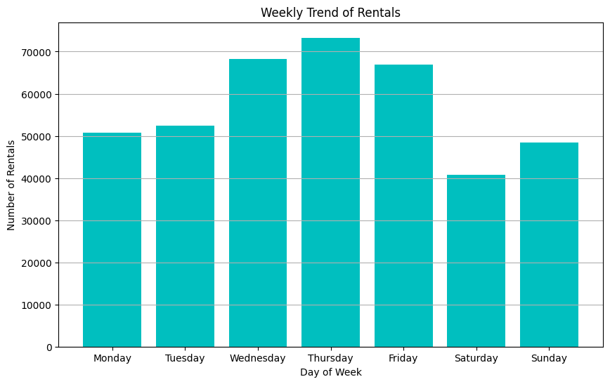

```python
detail_frequency['day_of_week'] = detail_frequency['started_at'].dt.day_name()
day_order = ['Monday', 'Tuesday', 'Wednesday', 'Thursday', 'Friday', 'Saturday', 'Sunday']
detail_frequency['day_of_week'] = pd.Categorical(detail_frequency['day_of_week'], categories=day_order, ordered=True)
weekly_trends = detail_frequency.groupby('day_of_week', observed=False).size()

plt.figure(figsize=(10, 6))
plt.bar(weekly_trends.index, weekly_trends, color='c')
plt.title('Weekly Trend of Rentals')
plt.xlabel('Day of Week')
plt.ylabel('Number of Rentals')
plt.grid(axis='y')
plt.show()
```

The chart shows the number of bike rentals for each day of the week.The chart shows that bike rentals are highest during the weekdays, peaking on Thursday. Weekend rentals, especially on Saturday, drop significantly.

This may suggest that the bike-sharing system is mainly used for weekday commuting, with much less activity on weekends, likely indicating lower use for leisure or recreational purposes.

#### Daily Trend

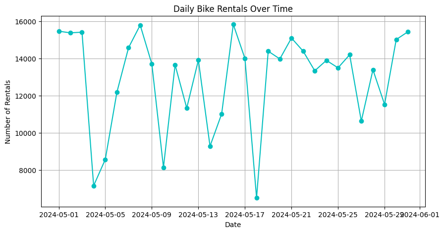

```python
detail_frequency['date'] = detail_frequency['started_at'].dt.date
daily_rentals = detail_frequency.groupby('date').size()
plt.figure(figsize=(10, 5))
plt.plot(daily_rentals.index, daily_rentals.values, marker='o', linestyle='-',color='c')
plt.title('Daily Bike Rentals Over Time')
plt.xlabel('Date')
plt.ylabel('Number of Rentals')
plt.grid(True)
plt.show()
```

Daily rentals fluctuate sharply throughout the month. Peaks may suggest high commuting or leisure use, while dips indicate lower activity on weekends or bad weather.

#### Hourly Trend

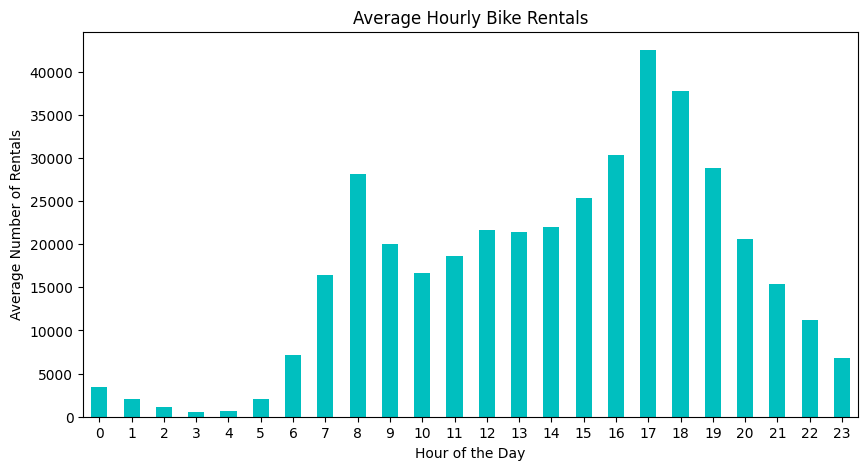

```python
detail_frequency['hour'] = detail_frequency['started_at'].dt.hour
hourly_rentals = detail_frequency.groupby([detail_frequency['started_at'].dt.date, 'hour']).size().unstack(fill_value=0)
average_hourly_rentals = detail_frequency.groupby('hour').size()

plt.figure(figsize=(10, 5))
average_hourly_rentals.plot(kind='bar', color='c')
plt.title('Average Hourly Bike Rentals')
plt.xlabel('Hour of the Day')
plt.ylabel('Average Number of Rentals')
plt.xticks(rotation=0)
plt.show()
```

There are two peaks in the day—around 8 AM and a higher peak between 5-6 PM, aligning with typical commute times. Rentals drop after 6 PM, with the lowest activity between 1-5 AM. The bike-sharing system is mainly used for commuting, with high demand during morning and evening rush hours on workdays.

### Rental Durations

```python
detail_frequency["duration"] = (
    detail_frequency["ended_at"] - detail_frequency["started_at"]
).dt.total_seconds() / 60
detail_frequency["is_overnight"] = (
    detail_frequency["ended_at"].dt.date > detail_frequency["started_at"].dt.date
)
overnight_count = detail_frequency["is_overnight"].sum()
print(f"Number of overnight rentals: {overnight_count}")
```

```
Number of overnight rentals: 1566
```

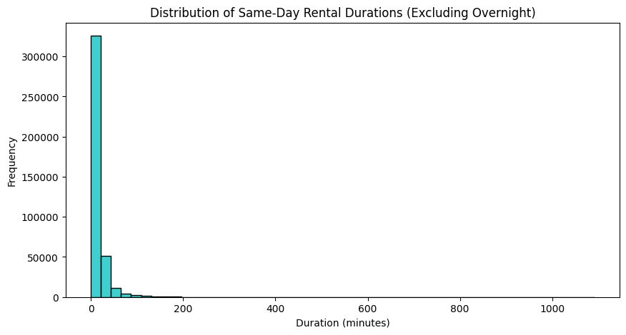

```python
same_day_rentals = detail_frequency[~detail_frequency["is_overnight"]]

plt.figure(figsize=(10, 5))
sns.histplot(data=same_day_rentals, x="duration", bins=50, color='c')
plt.title("Distribution of Same-Day Rental Durations (Excluding Overnight)")
plt.xlabel("Duration (minutes)")
plt.ylabel("Frequency")
plt.show()
```

After removing overnight rentals, the majority of bike rentals are short, indicating typical usage for quick trips. There are still a few outliers with longer durations, but these are rare.

### Rental Duration by User Type

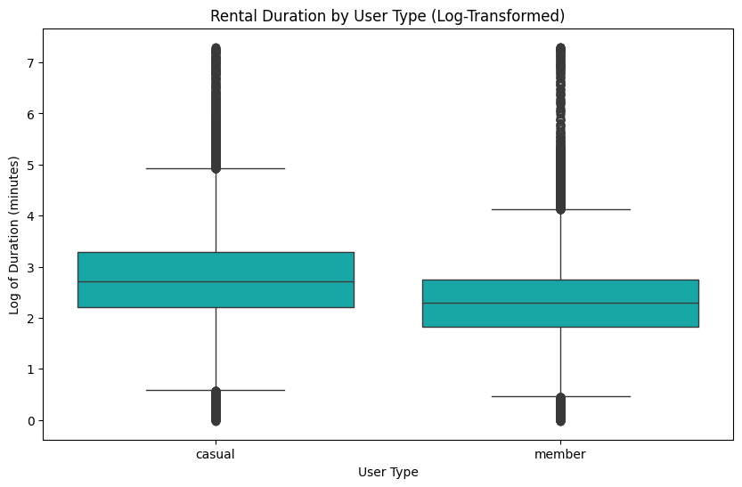

```python
detail_frequency['log_duration'] = np.log1p(detail_frequency['duration'])

plt.figure(figsize=(10, 6))
sns.boxplot(data=detail_frequency, x="member_casual", y="log_duration", color='c')
plt.title("Rental Duration by User Type (Log-Transformed)")
plt.xlabel("User Type")
plt.ylabel("Log of Duration (minutes)")
plt.show()
```

We use a log transformation to handle the wide range of rental durations and reduce the effect of extreme values. Casual users have longer and more variable rental durations than members, who tend to take shorter, more consistent trips. Casual users are likely using the service for leisure, while members use it primarily for commuting or regular short rides.

### Popular Pick Up Stations

We analyzed the top 20 most popular pickup stations to better understand the high-demand stations in bike-sharing usage.

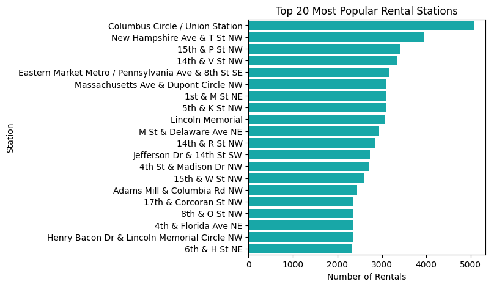

```python
station_counts = detail_frequency["start_station_name"].value_counts().reset_index()
station_counts.columns = ["start_station_name", "count"]
top_stations = station_counts.head(20)

plt.figure(figsize=(5, 5))
sns.barplot(data=top_stations, y="start_station_name", x="count",color='c')
plt.title("Top 20 Most Popular Rental Stations")
plt.xlabel("Number of Rentals")
plt.ylabel("Station")
plt.show()
```

The station at *Columbus Circle / Union Station* has the highest number of rentals, likely due to its proximity to transit points and major attractions. Other top stations are located near busy streets like *New Hampshire Ave & T St NW* and *15th & P St NW*, indicating high foot traffic in central urban areas. Tourist destinations such as *Lincoln Memorial and Henry Bacon Dr* also show significant activity, suggesting that bike-sharing is likely popular among visitors. Additionally, stations near key transportation hubs like *Eastern Market Metro* and *Massachusetts Ave & Dupont Circle NW* are heavily used for commuting purposes.

### Weather Conditions Overview

We created preliminary scatter plots to analyze the relationship between precipitation, average temperature, and pickup counts. This helps us understand whether environmental factors influence bike-sharing activity.

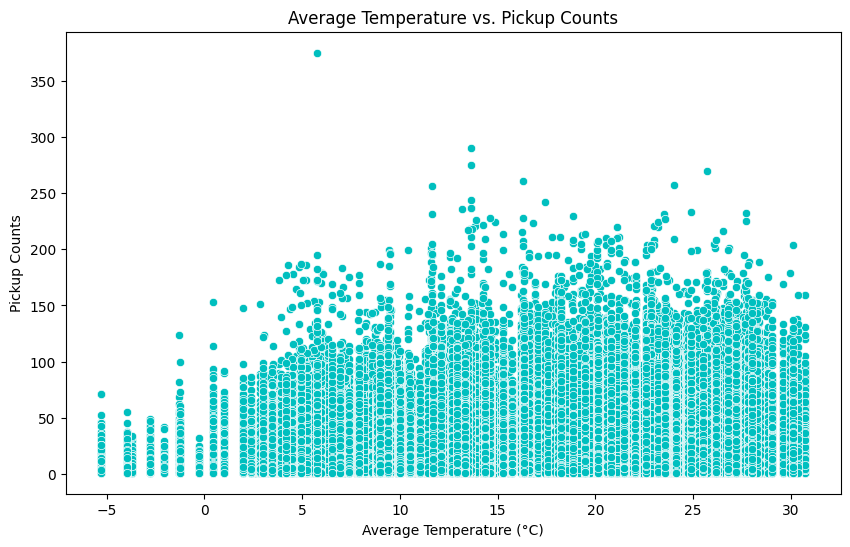

```python
weather_frequency['temp_avg'] = (weather_frequency['tempmax'] + weather_frequency['tempmin']) / 2
plt.figure(figsize=(10, 6))
sns.scatterplot(x='temp_avg', y='pickup_counts', data=weather_frequency, color='c')
plt.title('Average Temperature vs. Pickup Counts')
plt.xlabel('Average Temperature (°C)')
plt.ylabel('Pickup Counts')
plt.show()
```

As temperature increases, bike pickups rise, with the most activity between 10°C and 25°C, though higher temperatures still show variability. Moderate to warm temperatures lead to more bike rentals, but extreme temperatures see less activity, and temperature alone doesn't account for all variations in rentals.

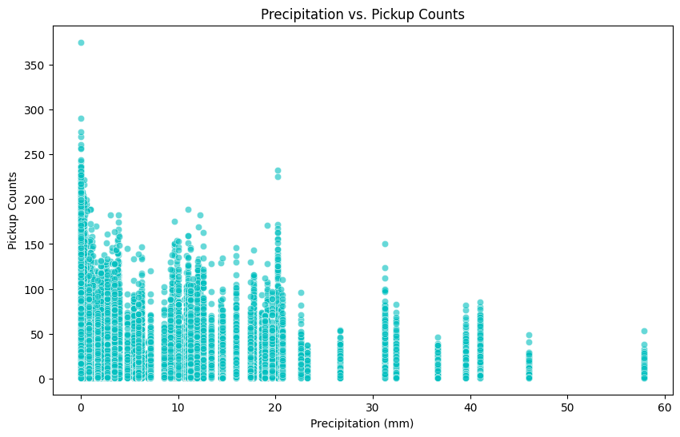

```python
plt.figure(figsize=(10, 6))
sns.scatterplot(x='precip', y='pickup_counts', data=weather_frequency, alpha=0.6, color='c')
plt.title('Precipitation vs. Pickup Counts')
plt.xlabel('Precipitation (mm)')
plt.ylabel('Pickup Counts')
plt.show()
```

The plot shows that bike rentals significantly decrease as precipitation increases. Most rentals occur when there is little to no rain (0-10mm). After about 20 mm of precipitation, the number of pickups drops sharply, and very few rentals are seen beyond 30 mm. This suggests that rain has a clear negative impact on bike-sharing usage, with people avoiding rentals on rainy days